# car

Introduction to Python

Kofi Anane Poku

Linkedin Profile : linkedin.com/in/kofi-poku-anane

Table of Contents

Github can't accept files that are more than 45MB , so i uploaded it to two storage cloud. You can download it and try your hands on it

Download Dataset from

1. https://files.fm/u/gra75ytpum
2. https://www.mediafire.com/file/gjq6uyymuv0h2z1/car.csv/file
3. https://drive.google.com/file/d/1CYA4znPjo8ifsG52pnCeiGE0CEZV60fD/view?usp=drive_link

```python
import pandas as pd
import plotly.express as px
import matplotlib.pyplot as plt
import seaborn as sns
import csv
import codecs
```

```python
with codecs.open ('./car.csv', 'r', encoding= 'ISO-8859-1') as f:
    car_analysis = pd.read_csv(f)
```

```python
car_analysis
```

|  | dateCrawled | name | seller | offerType | price | abtest | vehicleType | yearOfRegistration | gearbox | powerPS | model | kilometer | monthOfRegistration | fuelType | brand | notRepairedDamage | dateCreated | postalCode | lastSeen |
| --- | --- | --- | --- | --- | --- | --- | --- | --- | --- | --- | --- | --- | --- | --- | --- | --- | --- | --- | --- |
| 0 | 17/03/2016 16:54 | GOLF_4_1_4__3TÜRER | private | offer | 1500 | test | small car | 2001 | manual | 75 | golf | 150000 | 6 | petrol | volkswagen | no | 17/03/2016 0:00 | 91074 | 17/03/2016 17:40 |
| 1 | 31/03/2016 17:25 | Skoda_Fabia_1.4_TDI_PD_Classic | private | offer | 3600 | test | small car | 2008 | manual | 69 | fabia | 90000 | 7 | diesel | skoda | no | 31/03/2016 0:00 | 60437 | 06/04/2016 10:17 |
| 2 | 04/04/2016 17:36 | BMW_316i___e36_Limousine___Bastlerfahrzeug__Ex... | private | offer | 650 | test | limousine | 1995 | manual | 102 | 3er | 150000 | 10 | petrol | bmw | yes | 04/04/2016 0:00 | 33775 | 06/04/2016 19:17 |
| 3 | 01/04/2016 20:48 | Peugeot_206_CC_110_Platinum | private | offer | 2200 | test | cabrio | 2004 | manual | 109 | 2_reihe | 150000 | 8 | petrol | peugeot | no | 01/04/2016 0:00 | 67112 | 05/04/2016 18:18 |
| 4 | 21/03/2016 18:54 | VW_Derby_Bj_80__Scheunenfund | private | offer | 0 | test | limousine | 1980 | manual | 50 | others | 40000 | 7 | petrol | volkswagen | no | 21/03/2016 0:00 | 19348 | 25/03/2016 16:47 |
| ... | ... | ... | ... | ... | ... | ... | ... | ... | ... | ... | ... | ... | ... | ... | ... | ... | ... | ... | ... |
| 260960 | 19/03/2016 19:53 | turbo_defekt | private | offer | 3200 | control | limousine | 2004 | manual | 225 | leon | 150000 | 5 | petrol | seat | yes | 19/03/2016 0:00 | 96465 | 19/03/2016 20:44 |
| 260961 | 27/03/2016 20:36 | Opel_Zafira_1.6_Elegance_TÜV_12/16 | private | offer | 1150 | control | bus | 2000 | manual | 0 | zafira | 150000 | 3 | petrol | opel | no | 27/03/2016 0:00 | 26624 | 29/03/2016 10:17 |
| 260962 | 05/03/2016 19:56 | Smart_smart_leistungssteigerung_100ps | private | offer | 1199 | test | cabrio | 2000 | automatic | 101 | fortwo | 125000 | 3 | petrol | smart | no | 05/03/2016 0:00 | 26135 | 11/03/2016 18:17 |
| 260963 | 19/03/2016 18:57 | Volkswagen_Multivan_T4_TDI_7DC_UY2 | private | offer | 9200 | test | bus | 1996 | manual | 102 | transporter | 150000 | 3 | diesel | volkswagen | no | 19/03/2016 0:00 | 87439 | 07/04/2016 7:15 |
| 260964 | 07/03/2016 19:39 | BMW_M135i_vollausgestattet_NP_52.720____Euro | private | offer | 28990 | control | limousine | 2013 | manual | 320 | m_reihe | 50000 | 8 | petrol | bmw | no | 07/03/2016 0:00 | 73326 | 22/03/2016 3:17 |

260965 rows × 19 columns

```python
car_analysis.info()
car_analysis.dropna(inplace=True)
```

```
<class 'pandas.core.frame.DataFrame'>
RangeIndex: 260965 entries, 0 to 260964
Data columns (total 19 columns):
 #   Column               Non-Null Count   Dtype
---  ------               --------------   -----
 0   dateCrawled          260965 non-null  object
 1   name                 260965 non-null  object
 2   seller               260965 non-null  object
 3   offerType            260965 non-null  object
 4   price                260965 non-null  int64
 5   abtest               260965 non-null  object
 6   vehicleType          260965 non-null  object
 7   yearOfRegistration   260965 non-null  int64
 8   gearbox              260965 non-null  object
 9   powerPS              260965 non-null  int64
 10  model                260965 non-null  object
 11  kilometer            260965 non-null  int64
 12  monthOfRegistration  260965 non-null  int64
 13  fuelType             260965 non-null  object
 14  brand                260965 non-null  object
 15  notRepairedDamage    260965 non-null  object
 16  dateCreated          260965 non-null  object
 17  postalCode           260965 non-null  int64
 18  lastSeen             260965 non-null  object
dtypes: int64(6), object(13)
memory usage: 37.8+ MB
```

```python
car_analysis.isnull().sum()
```

```
dateCrawled            0
name                   0
seller                 0
offerType              0
price                  0
abtest                 0
vehicleType            0
yearOfRegistration     0
gearbox                0
powerPS                0
model                  0
kilometer              0
monthOfRegistration    0
fuelType               0
brand                  0
notRepairedDamage      0
dateCreated            0
postalCode             0
lastSeen               0
dtype: int64
```

Checking whether there's duplicates present in csv file

```python
car_analysis
```

|  | dateCrawled | name | seller | offerType | price | abtest | vehicleType | yearOfRegistration | gearbox | powerPS | model | kilometer | monthOfRegistration | fuelType | brand | notRepairedDamage | dateCreated | postalCode | lastSeen |
| --- | --- | --- | --- | --- | --- | --- | --- | --- | --- | --- | --- | --- | --- | --- | --- | --- | --- | --- | --- |
| 0 | 17/03/2016 16:54 | GOLF_4_1_4__3TÜRER | private | offer | 1500 | test | small car | 2001 | manual | 75 | golf | 150000 | 6 | petrol | volkswagen | no | 17/03/2016 0:00 | 91074 | 17/03/2016 17:40 |
| 1 | 31/03/2016 17:25 | Skoda_Fabia_1.4_TDI_PD_Classic | private | offer | 3600 | test | small car | 2008 | manual | 69 | fabia | 90000 | 7 | diesel | skoda | no | 31/03/2016 0:00 | 60437 | 06/04/2016 10:17 |
| 2 | 04/04/2016 17:36 | BMW_316i___e36_Limousine___Bastlerfahrzeug__Ex... | private | offer | 650 | test | limousine | 1995 | manual | 102 | 3er | 150000 | 10 | petrol | bmw | yes | 04/04/2016 0:00 | 33775 | 06/04/2016 19:17 |
| 3 | 01/04/2016 20:48 | Peugeot_206_CC_110_Platinum | private | offer | 2200 | test | cabrio | 2004 | manual | 109 | 2_reihe | 150000 | 8 | petrol | peugeot | no | 01/04/2016 0:00 | 67112 | 05/04/2016 18:18 |
| 4 | 21/03/2016 18:54 | VW_Derby_Bj_80__Scheunenfund | private | offer | 0 | test | limousine | 1980 | manual | 50 | others | 40000 | 7 | petrol | volkswagen | no | 21/03/2016 0:00 | 19348 | 25/03/2016 16:47 |
| ... | ... | ... | ... | ... | ... | ... | ... | ... | ... | ... | ... | ... | ... | ... | ... | ... | ... | ... | ... |
| 260960 | 19/03/2016 19:53 | turbo_defekt | private | offer | 3200 | control | limousine | 2004 | manual | 225 | leon | 150000 | 5 | petrol | seat | yes | 19/03/2016 0:00 | 96465 | 19/03/2016 20:44 |
| 260961 | 27/03/2016 20:36 | Opel_Zafira_1.6_Elegance_TÜV_12/16 | private | offer | 1150 | control | bus | 2000 | manual | 0 | zafira | 150000 | 3 | petrol | opel | no | 27/03/2016 0:00 | 26624 | 29/03/2016 10:17 |
| 260962 | 05/03/2016 19:56 | Smart_smart_leistungssteigerung_100ps | private | offer | 1199 | test | cabrio | 2000 | automatic | 101 | fortwo | 125000 | 3 | petrol | smart | no | 05/03/2016 0:00 | 26135 | 11/03/2016 18:17 |
| 260963 | 19/03/2016 18:57 | Volkswagen_Multivan_T4_TDI_7DC_UY2 | private | offer | 9200 | test | bus | 1996 | manual | 102 | transporter | 150000 | 3 | diesel | volkswagen | no | 19/03/2016 0:00 | 87439 | 07/04/2016 7:15 |
| 260964 | 07/03/2016 19:39 | BMW_M135i_vollausgestattet_NP_52.720____Euro | private | offer | 28990 | control | limousine | 2013 | manual | 320 | m_reihe | 50000 | 8 | petrol | bmw | no | 07/03/2016 0:00 | 73326 | 22/03/2016 3:17 |

260965 rows × 19 columns

```python
car_analysis.head()
```

|  | dateCrawled | name | seller | offerType | price | abtest | vehicleType | yearOfRegistration | gearbox | powerPS | model | kilometer | monthOfRegistration | fuelType | brand | notRepairedDamage | dateCreated | postalCode | lastSeen |
| --- | --- | --- | --- | --- | --- | --- | --- | --- | --- | --- | --- | --- | --- | --- | --- | --- | --- | --- | --- |
| 0 | 17/03/2016 16:54 | GOLF_4_1_4__3TÜRER | private | offer | 1500 | test | small car | 2001 | manual | 75 | golf | 150000 | 6 | petrol | volkswagen | no | 17/03/2016 0:00 | 91074 | 17/03/2016 17:40 |
| 1 | 31/03/2016 17:25 | Skoda_Fabia_1.4_TDI_PD_Classic | private | offer | 3600 | test | small car | 2008 | manual | 69 | fabia | 90000 | 7 | diesel | skoda | no | 31/03/2016 0:00 | 60437 | 06/04/2016 10:17 |
| 2 | 04/04/2016 17:36 | BMW_316i___e36_Limousine___Bastlerfahrzeug__Ex... | private | offer | 650 | test | limousine | 1995 | manual | 102 | 3er | 150000 | 10 | petrol | bmw | yes | 04/04/2016 0:00 | 33775 | 06/04/2016 19:17 |
| 3 | 01/04/2016 20:48 | Peugeot_206_CC_110_Platinum | private | offer | 2200 | test | cabrio | 2004 | manual | 109 | 2_reihe | 150000 | 8 | petrol | peugeot | no | 01/04/2016 0:00 | 67112 | 05/04/2016 18:18 |
| 4 | 21/03/2016 18:54 | VW_Derby_Bj_80__Scheunenfund | private | offer | 0 | test | limousine | 1980 | manual | 50 | others | 40000 | 7 | petrol | volkswagen | no | 21/03/2016 0:00 | 19348 | 25/03/2016 16:47 |

```python
car_analysis.columns
```

```
Index(['dateCrawled', 'name', 'seller', 'offerType', 'price', 'abtest',
       'vehicleType', 'yearOfRegistration', 'gearbox', 'powerPS', 'model',
       'kilometer', 'monthOfRegistration', 'fuelType', 'brand',
       'notRepairedDamage', 'dateCreated', 'postalCode', 'lastSeen'],
      dtype='object')
```

Finding Duplicated Columns

```python
duplicatedcolumns = car_analysis[car_analysis.duplicated()]
print('Duplicate Rows except first occurence based on all columns are:')
print(duplicatedcolumns)
```

```
Duplicate Rows except first occurence based on all columns are:
             dateCrawled                                               name  \
20284   23/03/2016 10:38  Opel_Zafira_1.7_CDTI_ecoFLEX_Edition_111_Jahre...
36259   13/03/2016 11:38  Volkswagen_Passat_Variant_1.6_TDI_BlueMotion_A...
44519   09/03/2016 22:47  Opel_Movano_EZ_2003_Diesel_Motor_2_8_Karosseri...
62595   03/04/2016 20:06  Fiat_500_1.3_Multijet__Lounge__Pano__Sonderedi...
70177   05/03/2016 14:16                               Suzuki_Swift_1.0_GLX
...                  ...                                                ...
240933   03/04/2016 9:56             A4_2.7tdi_Sportpaket_plus_::V8_Klang::
241009  03/04/2016 22:56                                        Mazda_323_F
247912  21/03/2016 16:42  Mercedes_Benz_E_200_T_CDI_Navi_AHK_Garantie__A...
254097  22/03/2016 18:47  BMW_320i_Touring_Automatik__110_kW_TÜV_bis_12....
255564  26/03/2016 15:51                            Ford_Focus_Turnier_Ghia

         seller offerType  price   abtest    vehicleType  yearOfRegistration  \
```

[output cut: 52 more lines]

Finding duplicated rows based on selected columns

```python
duplicatedrows = car_analysis.duplicated(['dateCrawled'])
print('Duplicated rows based on columns\n', duplicatedrows)
```

```
Duplicated rows based on columns
 0         False
1         False
2         False
3         False
4         False
          ...
260960     True
260961     True
260962     True
260963     True
260964     True
Length: 260965, dtype: bool
```

```python
car_analysis = car_analysis.drop_duplicates(keep=False)
car_analysis
```

|  | dateCrawled | name | seller | offerType | price | abtest | vehicleType | yearOfRegistration | gearbox | powerPS | model | kilometer | monthOfRegistration | fuelType | brand | notRepairedDamage | dateCreated | postalCode | lastSeen |
| --- | --- | --- | --- | --- | --- | --- | --- | --- | --- | --- | --- | --- | --- | --- | --- | --- | --- | --- | --- |
| 0 | 17/03/2016 16:54 | GOLF_4_1_4__3TÜRER | private | offer | 1500 | test | small car | 2001 | manual | 75 | golf | 150000 | 6 | petrol | volkswagen | no | 17/03/2016 0:00 | 91074 | 17/03/2016 17:40 |
| 1 | 31/03/2016 17:25 | Skoda_Fabia_1.4_TDI_PD_Classic | private | offer | 3600 | test | small car | 2008 | manual | 69 | fabia | 90000 | 7 | diesel | skoda | no | 31/03/2016 0:00 | 60437 | 06/04/2016 10:17 |
| 2 | 04/04/2016 17:36 | BMW_316i___e36_Limousine___Bastlerfahrzeug__Ex... | private | offer | 650 | test | limousine | 1995 | manual | 102 | 3er | 150000 | 10 | petrol | bmw | yes | 04/04/2016 0:00 | 33775 | 06/04/2016 19:17 |
| 3 | 01/04/2016 20:48 | Peugeot_206_CC_110_Platinum | private | offer | 2200 | test | cabrio | 2004 | manual | 109 | 2_reihe | 150000 | 8 | petrol | peugeot | no | 01/04/2016 0:00 | 67112 | 05/04/2016 18:18 |
| 4 | 21/03/2016 18:54 | VW_Derby_Bj_80__Scheunenfund | private | offer | 0 | test | limousine | 1980 | manual | 50 | others | 40000 | 7 | petrol | volkswagen | no | 21/03/2016 0:00 | 19348 | 25/03/2016 16:47 |
| ... | ... | ... | ... | ... | ... | ... | ... | ... | ... | ... | ... | ... | ... | ... | ... | ... | ... | ... | ... |
| 260960 | 19/03/2016 19:53 | turbo_defekt | private | offer | 3200 | control | limousine | 2004 | manual | 225 | leon | 150000 | 5 | petrol | seat | yes | 19/03/2016 0:00 | 96465 | 19/03/2016 20:44 |
| 260961 | 27/03/2016 20:36 | Opel_Zafira_1.6_Elegance_TÜV_12/16 | private | offer | 1150 | control | bus | 2000 | manual | 0 | zafira | 150000 | 3 | petrol | opel | no | 27/03/2016 0:00 | 26624 | 29/03/2016 10:17 |
| 260962 | 05/03/2016 19:56 | Smart_smart_leistungssteigerung_100ps | private | offer | 1199 | test | cabrio | 2000 | automatic | 101 | fortwo | 125000 | 3 | petrol | smart | no | 05/03/2016 0:00 | 26135 | 11/03/2016 18:17 |
| 260963 | 19/03/2016 18:57 | Volkswagen_Multivan_T4_TDI_7DC_UY2 | private | offer | 9200 | test | bus | 1996 | manual | 102 | transporter | 150000 | 3 | diesel | volkswagen | no | 19/03/2016 0:00 | 87439 | 07/04/2016 7:15 |
| 260964 | 07/03/2016 19:39 | BMW_M135i_vollausgestattet_NP_52.720____Euro | private | offer | 28990 | control | limousine | 2013 | manual | 320 | m_reihe | 50000 | 8 | petrol | bmw | no | 07/03/2016 0:00 | 73326 | 22/03/2016 3:17 |

260837 rows × 19 columns

```python
car_analysis_dupliactedRows=car_analysis[car_analysis.duplicated( keep=False)].shape[0]
if(car_analysis_dupliactedRows==0):
  print("There is no duplicate elements in csv file")
else:
  print("There is  duplicate elements in csv file")
```

```
There is no duplicate elements in csv file
```

```python
car_analysis.info()
```

```
<class 'pandas.core.frame.DataFrame'>
Index: 260837 entries, 0 to 260964
Data columns (total 19 columns):
 #   Column               Non-Null Count   Dtype
---  ------               --------------   -----
 0   dateCrawled          260837 non-null  object
 1   name                 260837 non-null  object
 2   seller               260837 non-null  object
 3   offerType            260837 non-null  object
 4   price                260837 non-null  int64
 5   abtest               260837 non-null  object
 6   vehicleType          260837 non-null  object
 7   yearOfRegistration   260837 non-null  int64
 8   gearbox              260837 non-null  object
 9   powerPS              260837 non-null  int64
 10  model                260837 non-null  object
 11  kilometer            260837 non-null  int64
 12  monthOfRegistration  260837 non-null  int64
 13  fuelType             260837 non-null  object
 14  brand                260837 non-null  object
 15  notRepairedDamage    260837 non-null  object
 16  dateCreated          260837 non-null  object
 17  postalCode           260837 non-null  int64
 18  lastSeen             260837 non-null  object
dtypes: int64(6), object(13)
memory usage: 39.8+ MB
```

```python
car_analysis.to_csv('C:/Users/toy/Desktop/project/carAnalysis/clean_cardata.csv', index=False)
```

Analysing the Car Data

Most expensive automobile

```python
most_expensive_car = car_analysis.sort_values(ascending=False, by='price')
most_expensive_car.head(10)
```

|  | dateCrawled | name | seller | offerType | price | abtest | vehicleType | yearOfRegistration | gearbox | powerPS | model | kilometer | monthOfRegistration | fuelType | brand | notRepairedDamage | dateCreated | postalCode | lastSeen |
| --- | --- | --- | --- | --- | --- | --- | --- | --- | --- | --- | --- | --- | --- | --- | --- | --- | --- | --- | --- |
| 97812 | 14/03/2016 12:49 | Mercedes_Benz_CLS_350_CDI_7G_TRONIC | private | offer | 99999999 | control | coupe | 2009 | automatic | 224 | others | 150000 | 11 | diesel | mercedes_benz | yes | 14/03/2016 0:00 | 56112 | 14/03/2016 22:40 |
| 89891 | 14/03/2016 17:49 | audi_a6_c5_avant | private | offer | 99999999 | test | station wagon | 1999 | manual | 165 | a6 | 5000 | 12 | petrol | audi | no | 14/03/2016 0:00 | 28325 | 14/03/2016 17:49 |
| 176989 | 21/03/2016 22:25 | Audi_A6_2.7_TDI_quattro_S_Line_Luftfederung_Bose | private | offer | 99000000 | test | limousine | 2009 | automatic | 190 | a6 | 150000 | 11 | diesel | audi | no | 21/03/2016 0:00 | 60433 | 25/03/2016 4:45 |
| 196677 | 03/04/2016 11:56 | Mercedes_Benz_CLK_Coupe_280_7G_TRONIC_Sport_Av... | private | offer | 14000500 | control | coupe | 2008 | automatic | 231 | clk | 125000 | 5 | petrol | mercedes_benz | no | 03/04/2016 0:00 | 40476 | 03/04/2016 11:56 |
| 169853 | 31/03/2016 18:56 | Opel_Vectra_B_1_6i_16V_Facelift_Tuning_Showcar... | private | offer | 12345678 | control | limousine | 2001 | manual | 101 | vectra | 150000 | 3 | petrol | opel | no | 31/03/2016 0:00 | 4356 | 31/03/2016 18:56 |
| 202254 | 26/03/2016 0:56 | tausche_o_verkaufe | private | offer | 12345678 | test | station wagon | 2001 | manual | 101 | focus | 150000 | 0 | petrol | ford | no | 26/03/2016 0:00 | 17291 | 01/04/2016 21:18 |
| 148006 | 12/03/2016 21:50 | Escort_MK_1_Hundeknochen_zum_umbauen_auf_RS_2000 | private | offer | 11111111 | test | limousine | 1973 | manual | 48 | escort | 50000 | 3 | petrol | ford | no | 12/03/2016 0:00 | 94469 | 12/03/2016 22:45 |
| 38164 | 08/03/2016 11:51 | Mazda_5_2.0_CD_DPF_Exclusive | private | offer | 10000000 | control | bus | 2007 | manual | 143 | 5_reihe | 150000 | 2 | diesel | mazda | no | 08/03/2016 0:00 | 83301 | 10/03/2016 14:17 |
| 15102 | 19/03/2016 19:45 | Porsche_911_911R_1_of_20_ORIGINAL_R_nur_798KG!... | private | offer | 9999999 | control | coupe | 1967 | manual | 215 | 911 | 50000 | 10 | petrol | porsche | no | 19/03/2016 0:00 | 70435 | 01/04/2016 10:45 |
| 64084 | 30/03/2016 19:46 | Verkaufe_oder_tausche_wenn_nur_gegen_Kombi_s4_... | private | offer | 9999999 | test | limousine | 1996 | manual | 380 | a4 | 60000 | 5 | petrol | audi | no | 30/03/2016 0:00 | 47800 | 30/03/2016 19:46 |

```python
expensive_cars = car_analysis.sort_values('price',ascending = False).head(2)
fig = px.bar(expensive_cars, x='brand', y='price', color='price')
fig.show()
```

[output not shown]

```python
car_analysis['dateCrawled'] = pd.to_datetime(car_analysis['dateCrawled'])
car_analysis['lastSeen'] = pd.to_datetime(car_analysis['lastSeen'])
car_analysis['dateCreated'] = pd.to_datetime(car_analysis['dateCreated'])
car_analysis
```

[output not shown]

|  | dateCrawled | name | seller | offerType | price | abtest | vehicleType | yearOfRegistration | gearbox | powerPS | model | kilometer | monthOfRegistration | fuelType | brand | notRepairedDamage | dateCreated | postalCode | lastSeen |
| --- | --- | --- | --- | --- | --- | --- | --- | --- | --- | --- | --- | --- | --- | --- | --- | --- | --- | --- | --- |
| 0 | 2016-03-17 16:54:00 | GOLF_4_1_4__3TÜRER | private | offer | 1500 | test | small car | 2001 | manual | 75 | golf | 150000 | 6 | petrol | volkswagen | no | 2016-03-17 | 91074 | 2016-03-17 17:40:00 |
| 1 | 2016-03-31 17:25:00 | Skoda_Fabia_1.4_TDI_PD_Classic | private | offer | 3600 | test | small car | 2008 | manual | 69 | fabia | 90000 | 7 | diesel | skoda | no | 2016-03-31 | 60437 | 2016-04-06 10:17:00 |
| 2 | 2016-04-04 17:36:00 | BMW_316i___e36_Limousine___Bastlerfahrzeug__Ex... | private | offer | 650 | test | limousine | 1995 | manual | 102 | 3er | 150000 | 10 | petrol | bmw | yes | 2016-04-04 | 33775 | 2016-04-06 19:17:00 |
| 3 | 2016-04-01 20:48:00 | Peugeot_206_CC_110_Platinum | private | offer | 2200 | test | cabrio | 2004 | manual | 109 | 2_reihe | 150000 | 8 | petrol | peugeot | no | 2016-04-01 | 67112 | 2016-04-05 18:18:00 |
| 4 | 2016-03-21 18:54:00 | VW_Derby_Bj_80__Scheunenfund | private | offer | 0 | test | limousine | 1980 | manual | 50 | others | 40000 | 7 | petrol | volkswagen | no | 2016-03-21 | 19348 | 2016-03-25 16:47:00 |
| ... | ... | ... | ... | ... | ... | ... | ... | ... | ... | ... | ... | ... | ... | ... | ... | ... | ... | ... | ... |
| 260960 | 2016-03-19 19:53:00 | turbo_defekt | private | offer | 3200 | control | limousine | 2004 | manual | 225 | leon | 150000 | 5 | petrol | seat | yes | 2016-03-19 | 96465 | 2016-03-19 20:44:00 |
| 260961 | 2016-03-27 20:36:00 | Opel_Zafira_1.6_Elegance_TÜV_12/16 | private | offer | 1150 | control | bus | 2000 | manual | 0 | zafira | 150000 | 3 | petrol | opel | no | 2016-03-27 | 26624 | 2016-03-29 10:17:00 |
| 260962 | 2016-03-05 19:56:00 | Smart_smart_leistungssteigerung_100ps | private | offer | 1199 | test | cabrio | 2000 | automatic | 101 | fortwo | 125000 | 3 | petrol | smart | no | 2016-03-05 | 26135 | 2016-03-11 18:17:00 |
| 260963 | 2016-03-19 18:57:00 | Volkswagen_Multivan_T4_TDI_7DC_UY2 | private | offer | 9200 | test | bus | 1996 | manual | 102 | transporter | 150000 | 3 | diesel | volkswagen | no | 2016-03-19 | 87439 | 2016-04-07 07:15:00 |
| 260964 | 2016-03-07 19:39:00 | BMW_M135i_vollausgestattet_NP_52.720____Euro | private | offer | 28990 | control | limousine | 2013 | manual | 320 | m_reihe | 50000 | 8 | petrol | bmw | no | 2016-03-07 | 73326 | 2016-03-22 03:17:00 |

260837 rows × 19 columns

```python
car_analysis.info()
```

```
<class 'pandas.core.frame.DataFrame'>
Index: 260837 entries, 0 to 260964
Data columns (total 19 columns):
 #   Column               Non-Null Count   Dtype
---  ------               --------------   -----
 0   dateCrawled          260837 non-null  datetime64[ns]
 1   name                 260837 non-null  object
 2   seller               260837 non-null  object
 3   offerType            260837 non-null  object
 4   price                260837 non-null  int64
 5   abtest               260837 non-null  object
 6   vehicleType          260837 non-null  object
 7   yearOfRegistration   260837 non-null  int64
 8   gearbox              260837 non-null  object
 9   powerPS              260837 non-null  int64
 10  model                260837 non-null  object
 11  kilometer            260837 non-null  int64
 12  monthOfRegistration  260837 non-null  int64
 13  fuelType             260837 non-null  object
 14  brand                260837 non-null  object
 15  notRepairedDamage    260837 non-null  object
 16  dateCreated          260837 non-null  datetime64[ns]
 17  postalCode           260837 non-null  int64
 18  lastSeen             260837 non-null  datetime64[ns]
dtypes: datetime64[ns](3), int64(6), object(10)
memory usage: 39.8+ MB
```

What is the average price of cars per analysis. Average price sets as benchmark for pricing strategies to prove accurate pricing

```python
average_price_of_cars = car_analysis['price'].mean()
print('Ghc',average_price_of_cars)
```

```
Ghc 8210.055272066464
```

```python
car_analysis.columns
```

```
Index(['dateCrawled', 'name', 'seller', 'offerType', 'price', 'abtest',
       'vehicleType', 'yearOfRegistration', 'gearbox', 'powerPS', 'model',
       'kilometer', 'monthOfRegistration', 'fuelType', 'brand',
       'notRepairedDamage', 'dateCreated', 'postalCode', 'lastSeen'],
      dtype='object')
```

Car Model

```python
car_analysis['model'].value_counts()
```

```
model
golf               20958
others             20288
3er                15637
polo                8824
corsa               8259
                   ...
i3                     5
rangerover             4
samara                 3
serie_3                3
discovery_sport        1
Name: count, Length: 250, dtype: int64
```

```python
car_analysis['model'].value_counts()
```

```
model
golf               20958
others             20288
3er                15637
polo                8824
corsa               8259
                   ...
i3                     5
rangerover             4
samara                 3
serie_3                3
discovery_sport        1
Name: count, Length: 250, dtype: int64
```

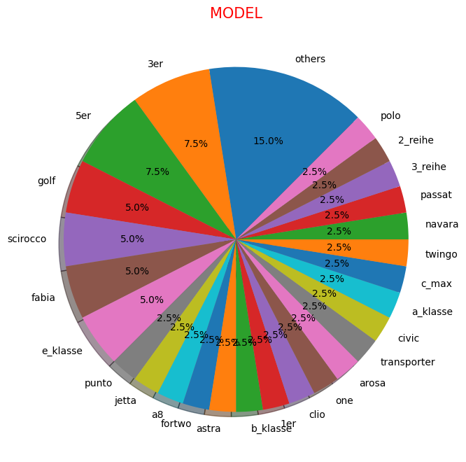

```python
labels = car_analysis["model"][:40].value_counts().index
sizes = car_analysis["model"][:40].value_counts()
#colors = ['#ff9999','#66b3ff','#99ff99','#ffcc99',"pink","yellow"]
plt.figure(figsize = (8,8))
plt.pie(sizes, labels=labels, rotatelabels=False, autopct='%1.1f%%',shadow=True, startangle=45)
plt.title('MODEL',color = 'red',fontsize = 15)
plt.show()
```

Car Model Observation of the graph shows others as most appearannce among the car models

Manual and Automatic

```python
car_analysis['gearbox'].value_counts()
```

```
gearbox
manual       199964
automatic     60873
Name: count, dtype: int64
```

```python
car_analysis.groupby('gearbox')['name'].value_counts()
```

```
gearbox    name
automatic  Volkswagen_Golf_2.0_GTI_DSG                           136
           Audi_A6_Avant_3.0_TDI_DPF_quattro_tiptronic           127
           BMW_525d_Touring_Aut.                                 124
           BMW_525d_Aut.                                         111
           Audi_A6_Avant_2.5_TDI                                 109
                                                                ...
manual     »Sommerauto«_Opel_Astra_F_Cabrio_"Bertone_Edition"      1
           »TWINGO_1.2«                                            1
           »_TWINGO_«                                              1
           »_gepflegter_VW_Passat_3c_TDI_abzugeben__!              1
           Über_ein_Jahr_fahrspass_mit_faltdach                    1
Name: count, Length: 153042, dtype: int64
```

Percentage of manual and automatic cars

```python
car_analysis['gearbox'].value_counts().sort_values()
```

```
gearbox
automatic     60873
manual       199964
Name: count, dtype: int64
```

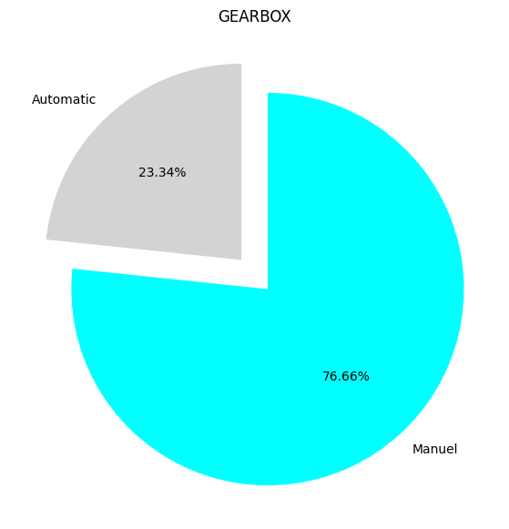

```python
plt.figure(figsize=(14, 7))
labels=['Automatic', 'Manuel']
plt.pie(car_analysis['gearbox'].value_counts().sort_values(),labels=labels,explode=[0.1,0.1],
        autopct='%1.2f%%',colors=['lightgray','cyan'], startangle=90)
plt.title('GEARBOX')
#plt.axis('equal')
plt.show()
```

Year Of Registration and Year Counts

```python
car_analysis.groupby('yearOfRegistration')['name'].value_counts()
```

```
yearOfRegistration  name
1910                Charleston_Pick_Up_Ente_2CV                                          1
                    Mercedes_Diesel_W_201                                                1
                    SUCHE_MERCEDES_BENZ_GL_LPG                                           1
1919                Ford_Model_T_1919                                                    1
1923                Citroën_C3                                                           1
                                                                                        ..
2017                bmw_523i_tip_tronik_multifunktions_lenkrad_ahk_abnehmbar             1
                    bmw_523i_tip_tronik_multifunktions_lenkrad_ahk_abnehmbar_tempomat    1
2018                Bmw_e36_318ti_Compact_TÜV_NEU                                        1
                    VW_Polo_1_4_9N_silbermet._TDI                                        1
                    VW_Polo_9N_1.2_Klima_Sitzheizung_TÜV_NEU_2.Hand                      1
Name: count, Length: 177907, dtype: int64
```

Car counts based on models per year

```python
car_analysis['yearOfRegistration'].sort_values()
```

```
72444     1910
101440    1910
199636    1910
145718    1919
238752    1923
          ...
39998     2017
72157     2017
174723    2018
60899     2018
117509    2018
Name: yearOfRegistration, Length: 260837, dtype: int64
```

```python
car_analysis.groupby('yearOfRegistration')['model'].count().reset_index().sort_values('model',ascending = False)
```

|  | yearOfRegistration | model |
| --- | --- | --- |
| 76 | 2006 | 16797 |
| 69 | 1999 | 16086 |
| 75 | 2005 | 15951 |
| 74 | 2004 | 15703 |
| 73 | 2003 | 15555 |
| ... | ... | ... |
| 7 | 1933 | 1 |
| 17 | 1947 | 1 |
| 3 | 1929 | 1 |
| 18 | 1948 | 1 |
| 1 | 1919 | 1 |

89 rows × 2 columns

```python
cars_by_model_year = car_analysis.groupby('yearOfRegistration')['model'].count().reset_index().sort_values('model',ascending = False)
cars_by_model_year = cars_by_model_year[cars_by_model_year['yearOfRegistration'] >= 2001]
fig = px.bar(cars_by_model_year, x='yearOfRegistration', y='model')
fig.show()
```

[output not shown]

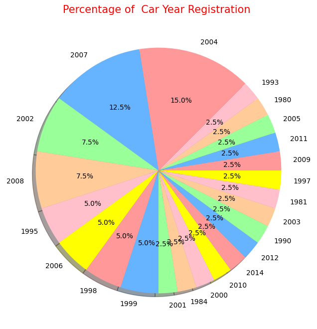

```python
labels = car_analysis["yearOfRegistration"][:40].value_counts().index
sizes = car_analysis["yearOfRegistration"][:40].value_counts()
colors = ['#ff9999','#66b3ff','#99ff99','#ffcc99',"pink","yellow"]
plt.figure(figsize = (8,8))
plt.pie(sizes, labels=labels, rotatelabels=False, autopct='%1.1f%%',colors=colors,shadow=True, startangle=45)
plt.title('Percentage of  Car Year Registration ',color = 'red',fontsize = 15)
plt.show()
```

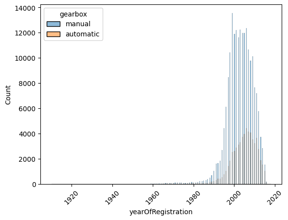

```python
sns.histplot(data=car_analysis, x="yearOfRegistration", hue='gearbox')
plt.xticks(rotation=45)
plt.show()
```

Most Common Serviced Car

```python
car_analysis['vehicleType'].value_counts()
```

```
vehicleType
limousine        76376
small car        59072
station wagon    53406
bus              24954
cabrio           18544
coupe            14632
suv              12081
others            1772
Name: count, dtype: int64
```

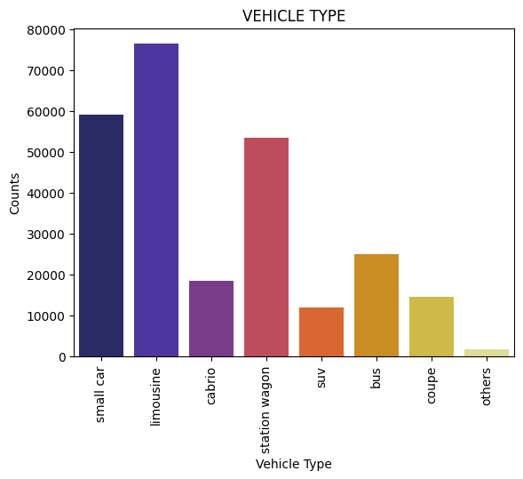

```python
sns.countplot( data=car_analysis, x='vehicleType' ,palette='CMRmap')
plt.xticks(rotation=90)
plt.xlabel('Vehicle Type', fontsize=10,color='black')
plt.ylabel('Counts', fontsize=10, color='black')
plt.title('VEHICLE TYPE', color="black")
plt.show()
```

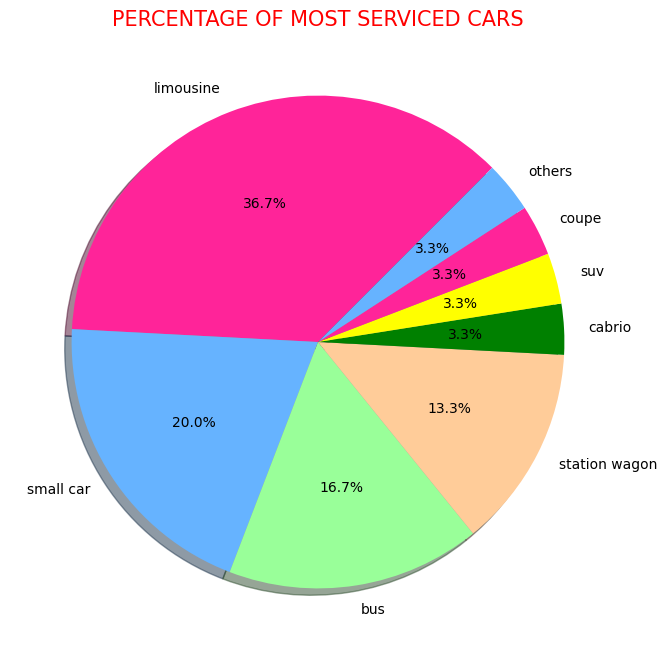

```python
labels = car_analysis["vehicleType"][:30].value_counts().index
sizes = car_analysis["vehicleType"][:30].value_counts()
colors = ['#ff2499','#66b3ff','#99ff99','#ffcc99',"green","yellow"]
plt.figure(figsize = (8,8))
plt.pie(sizes, labels=labels, rotatelabels=False, autopct='%1.1f%%',colors=colors,shadow=True, startangle=45)
plt.title('PERCENTAGE OF MOST SERVICED CARS',color = 'red',fontsize = 15)
plt.show()
```

AB TESTING

```python
#car_analysis['abtest'].isin(['test'])

car_analysis.abtest.value_counts()
```

```
abtest
test       135472
control    125365
Name: count, dtype: int64
```

Fuel Type

```python
car_analysis['fuelType'].value_counts()
```

```
fuelType
petrol     169160
diesel      86938
lpg          3935
cng           460
hybrid        214
other          73
electro        57
Name: count, dtype: int64
```

Th Relation between gearbox and kind of fuel it accept and shows the distribution of manual and automatic cars by years.

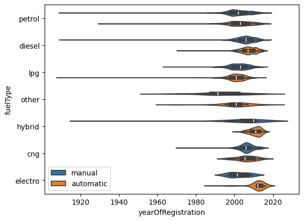

```python
sns.violinplot(data=car_analysis, x="yearOfRegistration", y="fuelType",hue="gearbox")
plt.legend(loc='lower left')
plt.show()
```

```python
car_analysis.groupby('name')['fuelType'].value_counts()
```

```
name                                                                fuelType
!!!!!!!!!!!!!!!!!!!!!!!!__GOLF_3_CABRIO___!!!!!!!!!!!!!!!!!!!!!!!   petrol      1
!!!!!!!!!!!!!!Renault_Clio_5_Tuerig_Servolenkung_!!!!!!!!!!!!!!!!!  petrol      1
!!!!!!!!!!!!_Seat_Toledo_1M_!!!!!!!!!!!                             petrol      1
!!!!!!!!BMW_530D_Touring_Vollausstattung!!!!!!                      diesel      1
!!!!!!!!_SCHROTT!!!!!!!!                                            petrol      1
                                                                               ..
»_gepflegter_VW_Passat_3c_TDI_abzugeben__!                          diesel      1
Äusserst_gut_geplegtes_CLK_Cabrio                                   petrol      1
Ökologisch___Elektrisch___Bezahlbar.__Fiat_New_500E                 electro     1
Über_ein_Jahr_fahrspass_mit_faltdach                                petrol      1
Übernahme_Leasingvertrag                                            petrol      1
Name: count, Length: 151914, dtype: int64
```

The observation shows that many of the cars used petrol and are manuel based on the voilent graph declaring the results

The table below shows most common type of fuel is petrol, followed by diesel.

```python
top3 = car_analysis['fuelType'].value_counts().head(3)
top3
```

```
fuelType
petrol    169160
diesel     86938
lpg         3935
Name: count, dtype: int64
```

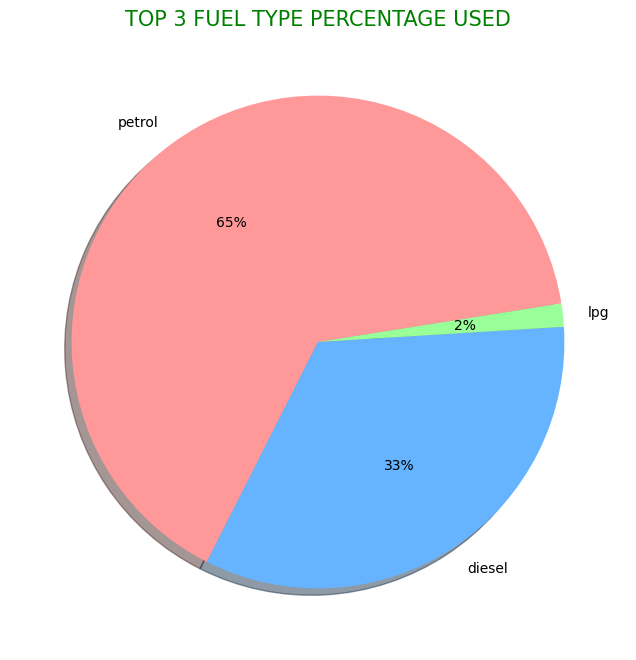

```python
labels = top3.index
sizes = top3
colors = ['#ff9999','#66b3ff','#99ff99','#ffcc99',"pink","yellow"]
plt.figure(figsize = (8,8))
plt.pie(sizes, labels=labels, rotatelabels=False, autopct='%1.f%%',colors=colors,shadow=True, startangle=9)
plt.title('TOP 3 FUEL TYPE PERCENTAGE USED',color = 'green',fontsize = 15)
plt.show()
```

Brand

```python
car_analysis['brand'].value_counts()
```

```
brand
volkswagen       54180
bmw              30317
mercedes_benz    26896
opel             26372
audi             24756
ford             17434
renault          11668
peugeot           7845
fiat              6361
seat              5017
skoda             4534
mazda             4035
toyota            3704
citroen           3688
nissan            3592
smart             3350
mini              2877
hyundai           2785
volvo             2588
mitsubishi        2075
kia               1966
honda             1946
porsche           1866
alfa_romeo        1704
suzuki            1679
chevrolet         1348
chrysler          1025
dacia              723
land_rover         636
jeep               616
subaru             550
daihatsu           520
jaguar             487
saab               421
daewoo             337
lancia             320
rover              262
trabant            211
lada               146
Name: count, dtype: int64
```

```python
top10 =  car_analysis.brand.head(10)
top10
```

```
0    volkswagen
1         skoda
2           bmw
3       peugeot
4    volkswagen
5         mazda
6    volkswagen
7        nissan
8       renault
9          ford
Name: brand, dtype: object
```

[figure not shown]

```python
labels = top10.value_counts().index
sizes = top10.value_counts()
colors = ['#ff9999','#66b3ff','#99ff99','#ffcc99',"pink","yellow"]
plt.figure(figsize = (8,8))
plt.pie(sizes, labels=labels, rotatelabels=False, autopct='%1.f%%',colors=colors,shadow=True, startangle=9)
plt.title('TOP 10 BRAND',color = 'black',fontsize = 15)
plt.show()
```

Numbers of cars per brand ,first 10 cars

```python
cars_per_brand = car_analysis.groupby('brand')['model'].count().reset_index().sort_values('model',ascending = False).head(10)
fig = px.bar(cars_per_brand, x='brand', y='model')
fig.show()
```

[output not shown]